# Regresja liniowa

- **Analityczna regresja** wykorzystuje wzór matematyczny – szybka, ale wrażliwa na problemy z macierzą.
- **Numeryczna regresja** opiera się na optymalizacji – działa zawsze, ale może być wolniejsza.

## Zadanie na 3

Porównanie analitycznej i numerycznej implementacji regresji na syntetycznym zbiorze

### Import bibliotek

```python
import numpy as np
from sklearn.datasets import make_regression
from scipy.optimize import minimize
import matplotlib.pyplot as plt
import pandas as pd
```

### Generowanie zbioru danych

Wygenerowanie jednowymiarowego zbioru. Dane wejściowe X_raw (cechy) i y_raw (wartości do przewidzenia).

```python
my_index = 259199
my_n_samples = int(str(my_index)[0]+ str(my_index)[1] + str(my_index)[-2] + str(my_index)[-1])
X_raw, y_raw = make_regression(n_samples=my_n_samples, n_features=1, noise=16, random_state=my_index)
```

Dodanie baiasu, bo bez niego linia regresji zawsze przechodziłaby przez punkt (0,0), co nie jest pożądane w większości przypadków.

```python
X = np.vstack([X_raw.T, np.ones(X_raw.shape[0])])
y = y_raw.reshape(1, -1)

print("X", X.shape)
print("y", y.shape)
```

```
X (2, 2599)
y (1, 2599)
```

### Regresja analityczna

y = ax + b

w[0] to współczynnik kierunkowy a

w[1] to wyraz wolny b

Używamy wzoru: w = (X Xᵀ)⁻¹ X yᵀ

```python
def analytical_linear_regression(X, y):
    Xt = X.T
    w = np.linalg.inv(X @ Xt) @ X @ y.T
    w = w.flatten()
    return w[0], w[1]
```

### Regresja numeryczna

Zamiast obliczać wzór, szukamy minimum funkcji błędu (średni błąd kwadratowy) iteracyjnie (np. scipy.optimize.minimize). Należy używać gdy danych jest dużo, są nieliniowe lub źle uwarunkowane

Używamy scipy.optimize.minimize, by znaleźć najlepsze a i b.

```python
def loss(w, X, y):
    w = w.reshape(-1, 1)
    predictions = X.T @ w
    return np.mean((y.T - predictions) ** 2)

def numerical_linear_regression(X, y):
    D = X.shape[0]
    w0 = np.zeros(D)
    result = minimize(loss, w0, args=(X, y), method='Powell')
    return result.x[0], result.x[1]
```

### Porównanie wyników

```python
a_an, b_an = analytical_linear_regression(X, y)
a_num, b_num = numerical_linear_regression(X, y)

print(f"Analityczna regresja: y = {a_an}x + {b_an}")
print(f"Numeryczna regresja: y = {a_num}x + {b_num}")
```

```
Analityczna regresja: y = 94.84239886493658x + -0.08880089212409273
Numeryczna regresja: y = 94.84239885167298x + -0.08880088504811817
```

Porównanie czasów 100 wyników

```python
import time

iterations = 100

start_time_analytical = time.time()
for _ in range(iterations):
    analytical_linear_regression(X, y)
end_time_analytical = time.time()

start_time_numerical = time.time()
for _ in range(iterations):
    numerical_linear_regression(X, y)
end_time_numerical = time.time()

time_analytical = end_time_analytical - start_time_analytical
time_numerical = end_time_numerical - start_time_numerical

print(f"Czas wykonania analytical_linear_regression dla {iterations} iteracji: {time_analytical:.4f} sekund")
print(f"Czas wykonania numerical_linear_regression dla {iterations} iteracji: {time_numerical:.4f} sekund")
```

```
Czas wykonania analytical_linear_regression dla 100 iteracji: 0.0650 sekund
Czas wykonania numerical_linear_regression dla 100 iteracji: 0.2620 sekund
```

### Wizualizacja wyników

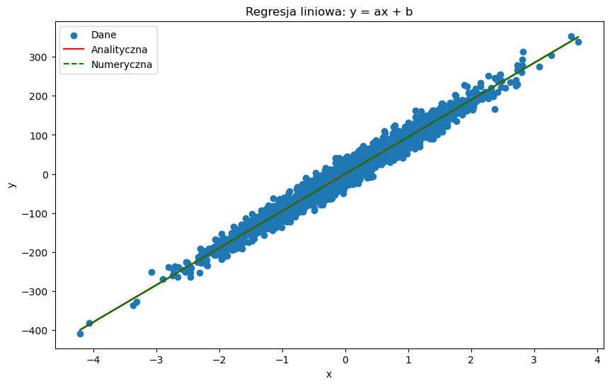

```python
x_vals = X_raw[:len(y_raw), 0]
y_vals = y.flatten()

y_pred_analytical = a_an * x_vals + b_an
y_pred_numerical = a_num * x_vals + b_num

plt.figure(figsize=(10,6))
plt.scatter(x_vals, y_vals, label='Dane')
plt.plot(x_vals, y_pred_analytical, label='Analityczna', color='red')
plt.plot(x_vals, y_pred_numerical, label='Numeryczna', color='green', linestyle='--')
plt.xlabel('x')
plt.ylabel('y')
plt.title('Regresja liniowa: y = ax + b')
plt.legend()
plt.show()
```

### Wniosek

- Regresja analityczna jest szybsza w małym zbiorze danych.
- Oba wyniki są do siebie bardzo zbliżone.

## Zadanie na 4

Porównanie sklearn i analitycznej implementacji regresji na zbiorze FlapPy Bird

### Napisanie funkcji z wykorzystaniem PolynomialFeatures i LinearRegression

```python
from sklearn.linear_model import LinearRegression
from sklearn.preprocessing import PolynomialFeatures
from sklearn.metrics import mean_squared_error

def polynomial_regression(x, y, degree):
    poly = PolynomialFeatures(degree=degree)
    X_poly = poly.fit_transform(x.reshape(-1, 1))

    model = LinearRegression()
    model.fit(X_poly, y)

    y_pred = model.predict(X_poly)

    mse = mean_squared_error(y, y_pred)

    return y_pred, mse
```

Własny model regresji

```python
def analytical_polynomial_regression(X, y, degree):
    if X.ndim == 1:
        X = X.reshape(-1, 1)

    X_poly = np.ones((X.shape[0], degree + 1))
    for d in range(1, degree + 1):
        X_poly[:, d] = X[:, 0] ** d

    Xt = X_poly.T
    w = np.linalg.inv(Xt @ X_poly) @ Xt @ y

    y_pred = X_poly @ w
    mse = np.mean((y - y_pred) ** 2)

    return y_pred, mse
```

### Pobranie danych z plików csv

```python
def get_data(file_name):
    file_path = f'./datasets/flappy/{file_name}.csv'
    data = pd.read_csv(file_path, header=None, names=['x', 'y'])

    x = np.array(data['x'].values)
    y = np.array(data['y'].values)

    return x, y

x_all_points, y_all_points = get_data('all_points')
x_min_points, y_min_points = get_data('min_points')
x_only_changes, y_only_changes = get_data('only_changes')


print("all_points", x_all_points.shape, y_all_points.shape)
print("min_points", x_min_points.shape, y_min_points.shape)
print("only_changes", x_only_changes.shape, y_only_changes.shape)
```

```
all_points (1443,) (1443,)
min_points (42,) (42,)
only_changes (187,) (187,)
```

```python
from sklearn.preprocessing import MinMaxScaler

def minimize_data(x, y):
    scaler = MinMaxScaler(feature_range=(-1, 1))
    x_minimized = scaler.fit_transform(x.reshape(-1, 1)).flatten()
    y_minimized = scaler.fit_transform(y.reshape(-1, 1)).flatten()

    return x_minimized, y_minimized

x_all_minimized, y_all_minimized = minimize_data(x_all_points, y_all_points)
x_min_minimized, y_min_minimized = minimize_data(x_min_points, y_min_points)
x_changes_minimized, y_changes_minimized = minimize_data(x_only_changes, y_only_changes)
```

Podział danych na zbiory

```python
datasets = [
    ("all_points", x_all_minimized, y_all_minimized),
    ("min_points", x_min_minimized, y_min_minimized),
    ("only_changes", x_changes_minimized, y_changes_minimized)
]

degrees = [9, 21]
```

Funkcja do wizualizacji wyników

```python
def plot_results(x, y, y_pred, title):
    plt.figure(figsize=(10, 6))
    plt.scatter(x, y, label='Dane', color='blue')
    plt.plot(x, y_pred, label='Regresja', color='red')
    plt.xlabel('x')
    plt.ylabel('y')
    plt.title(title)
    plt.legend()
    plt.show()
```

### Wizualizacja wyników

```
Regresja z sklearn
Zbiór danych: all_points
Liczba punktów: 1443
Stopień wielomianu: 9, MSE: 0.01678093826011653
```

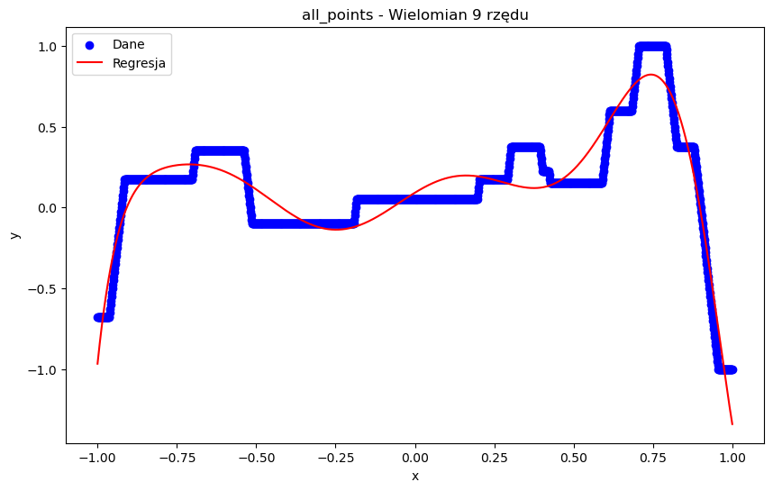

```
Stopień wielomianu: 21, MSE: 0.004057652638707231
```

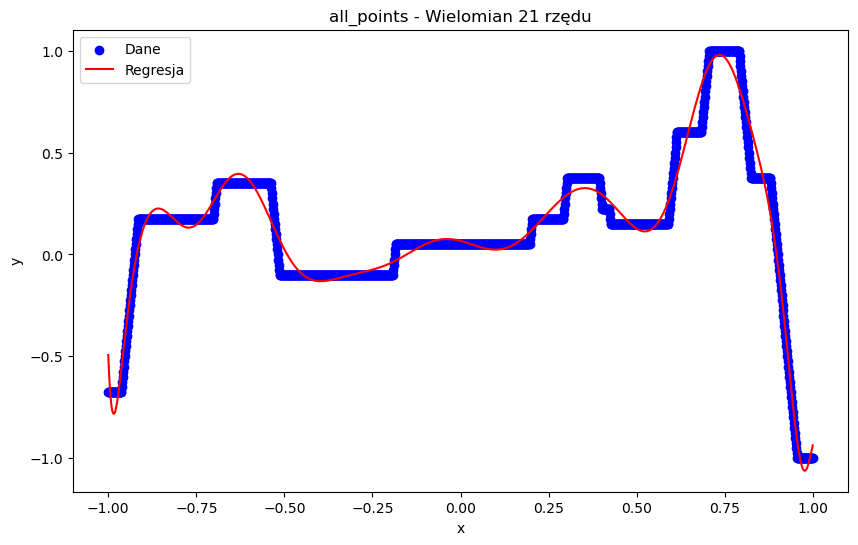

```
Zbiór danych: min_points
Liczba punktów: 42
Stopień wielomianu: 9, MSE: 0.016459791363805272
```

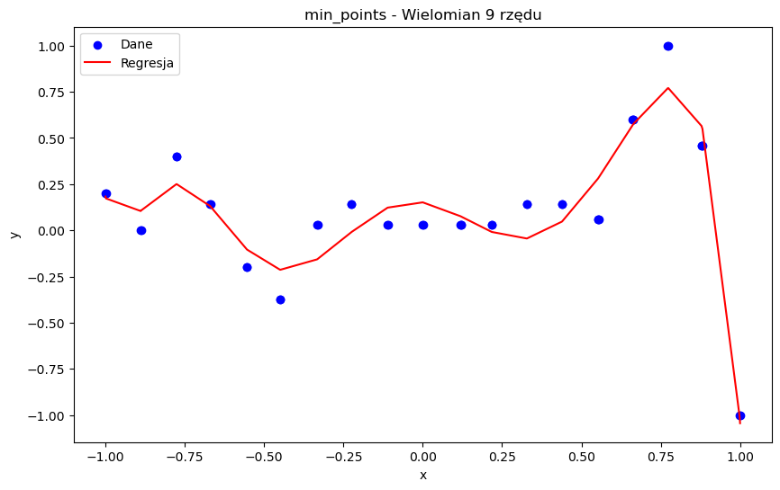

```
Stopień wielomianu: 21, MSE: 1.3136504747404201e-05
```

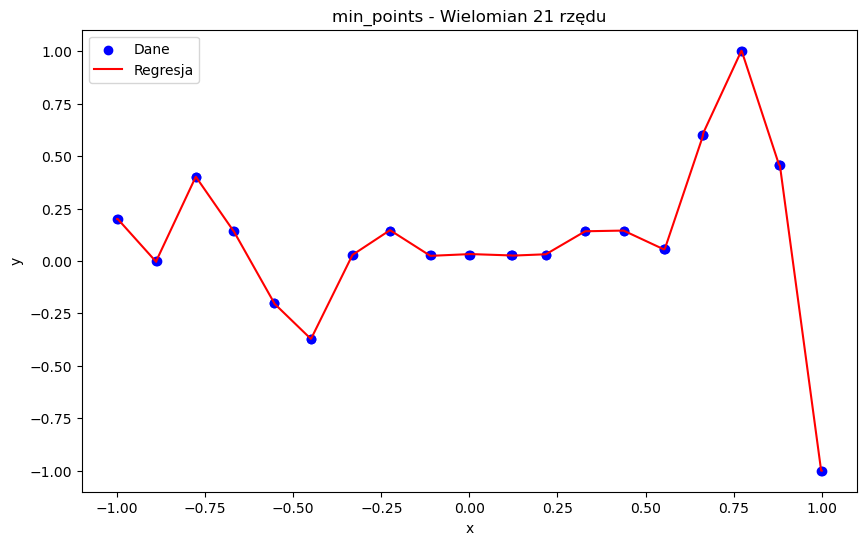

```
Zbiór danych: only_changes
Liczba punktów: 187
Stopień wielomianu: 9, MSE: 0.010576392414413776
```

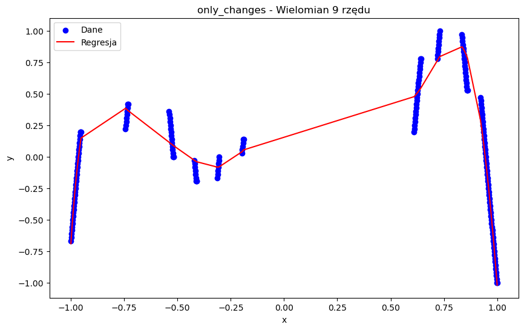

```
Stopień wielomianu: 21, MSE: 0.0011738169372955969
```

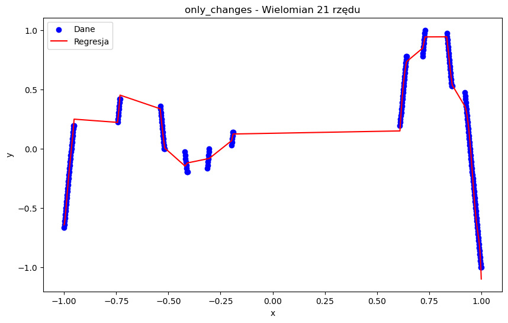

```
Regresja z własną funkcją
Zbiór danych: all_points
Liczba punktów: 1443
Stopień wielomianu: 9, MSE: 0.016780938260116538
```

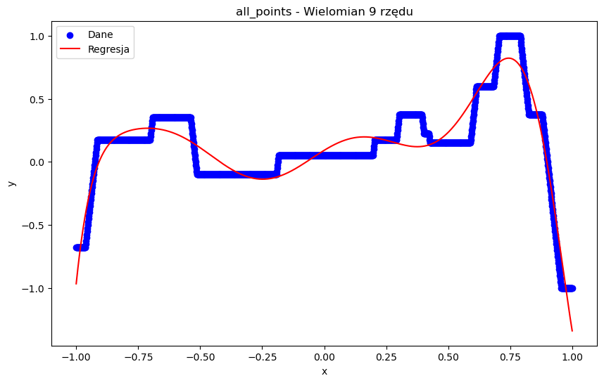

```
Stopień wielomianu: 21, MSE: 0.004058016611362836
```

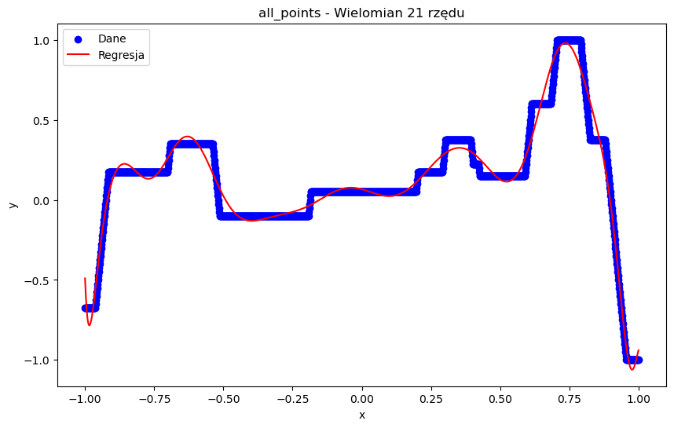

```
Zbiór danych: min_points
Liczba punktów: 42
Stopień wielomianu: 9, MSE: 0.01645979136380523
```

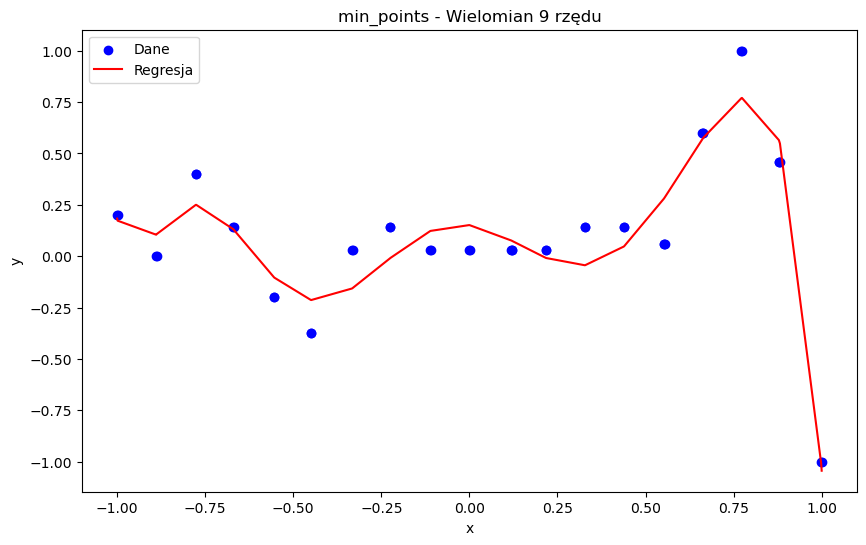

```
Stopień wielomianu: 21, MSE: 0.00015917522815984858
```

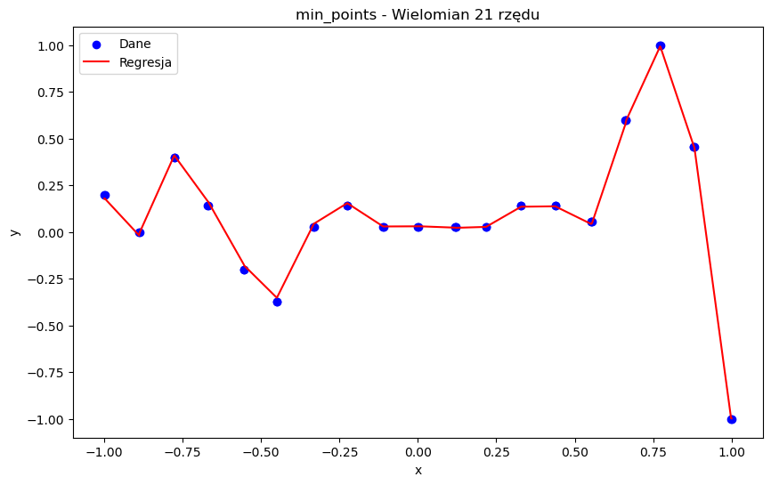

```
Zbiór danych: only_changes
Liczba punktów: 187
Stopień wielomianu: 9, MSE: 0.010576392414413799
```

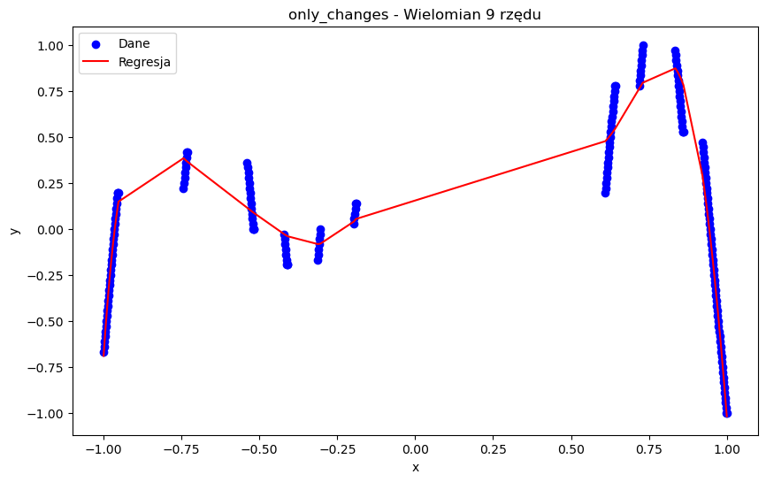

```
Stopień wielomianu: 21, MSE: 0.0018064803460340814
```

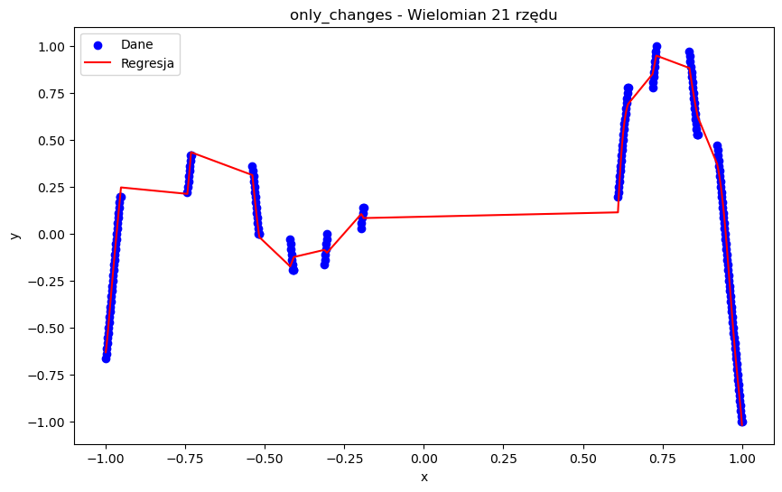

```python
mse_results = {"Sklearn": [], "Analytical": []}
labels = []

print("Regresja z sklearn")
for name, x, y in datasets:
    print(f"Zbiór danych: {name}\nLiczba punktów: {len(x)}")
    for degree in degrees:
        y_pred, mse = polynomial_regression(x, y, degree)
        mse_results["Sklearn"].append(mse)
        print(f"Stopień wielomianu: {degree}, MSE: {mse}")
        plot_results(x, y, y_pred, f"{name} - Wielomian {degree} rzędu")

print("Regresja z własną funkcją")
for name, x, y in datasets:
    print(f"Zbiór danych: {name} \nLiczba punktów: {len(x)}")
    for degree in degrees:
        y_pred, mse = analytical_polynomial_regression(x, y, degree)
        mse_results["Analytical"].append(mse)
        print(f"Stopień wielomianu: {degree}, MSE: {mse}")
        plot_results(x, y, y_pred, f"{name} - Wielomian {degree} rzędu")
```

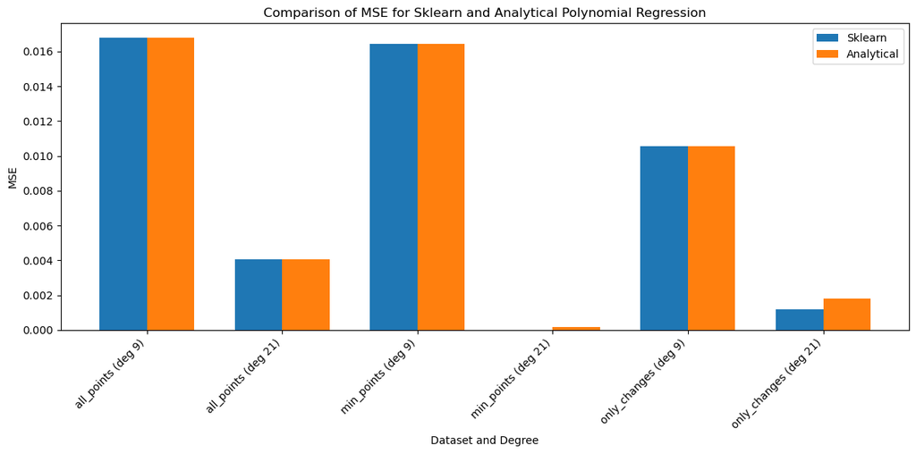

```python
labels = [name for name, _, _ in datasets]

x_labels = [f"{name} (deg {degree})" for name in labels for degree in degrees]
x = np.arange(len(x_labels))

width = 0.35
plt.figure(figsize=(12, 6))
plt.bar(x - width/2, mse_results["Sklearn"], width, label="Sklearn")
plt.bar(x + width/2, mse_results["Analytical"], width, label="Analytical")
plt.xlabel("Dataset and Degree")
plt.ylabel("MSE")
plt.title("Comparison of MSE for Sklearn and Analytical Polynomial Regression")
plt.xticks(x, x_labels, rotation=45, ha="right")
plt.legend()
plt.tight_layout()
plt.show()
```

## Zadanie na 5

Analityczną wersja regresji z regularyzacją Tichonowa (ridge regression). Porównanie działania własnej implementacji z sklearn.linear_model.Ridge na zebranych zbiorach.

### Własna implementacja regresji z regularyzacją Tichpova

```python
def regression_with_Tichonov(x, y, alpha, degree):
    X = np.vstack([x**d for d in range(degree + 1)]).T
    Xt = X.T
    I = np.eye(X.shape[1])

    w = np.linalg.inv(Xt @ X + alpha * I) @ Xt @ y
    y_pred = X @ w

    mse = np.mean((y - y_pred) ** 2)

    return y_pred, mse
```

### Regresja z wykorzystaniem model.Ridge

```python
from sklearn.linear_model import Ridge

def regression_with_Tichonov_model_ridge(x, y, alpha, degree):
    poly = PolynomialFeatures(degree=degree)
    X_poly = poly.fit_transform(x.reshape(-1, 1))

    model = Ridge(alpha=alpha)
    model.fit(X_poly, y)

    y_pred = model.predict(X_poly)
    mse = mean_squared_error(y, y_pred)

    return y_pred, mse
```

### Przygotowanie danych

```python
datasets = [
    ("all_points", x_all_minimized, y_all_minimized),
    ("min_points", x_min_minimized, y_min_minimized),
    ("only_changes", x_changes_minimized, y_changes_minimized)
]

alpha = 0.001
degree = 16
```

### Porównanie 2 algorytmów

```
Porównanie algorytmów Tichonova
Zbiór danych: all_points
Liczba punktów: 1443
Własna implementacja - MSE: 0.012587115067209099
```

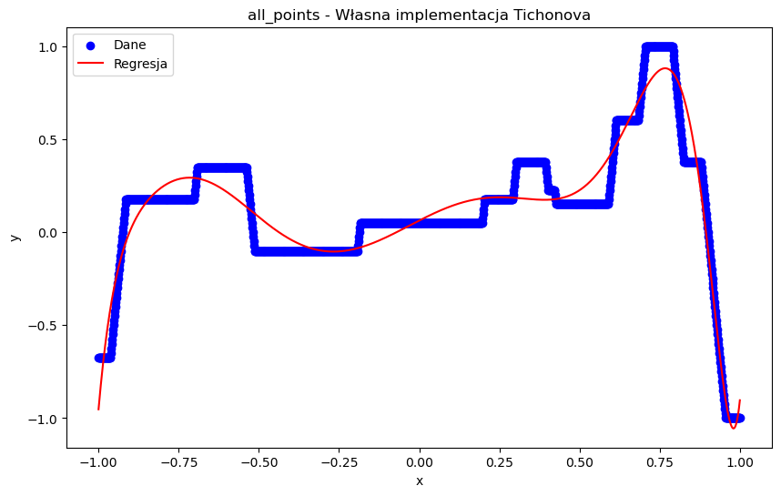

```
Sklearn Ridge - MSE: 0.012587115240390277
```

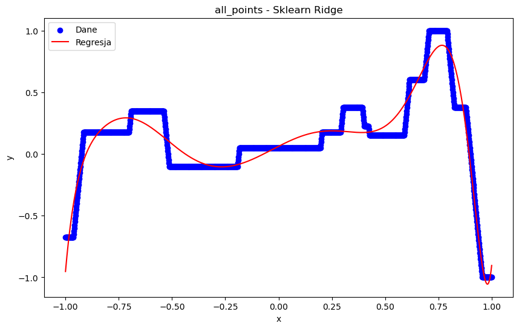

```
Zbiór danych: min_points
Liczba punktów: 42
Własna implementacja - MSE: 0.010756447009939375
```

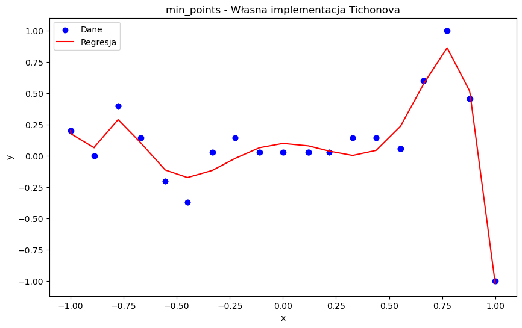

```
Sklearn Ridge - MSE: 0.010756330594285938
```

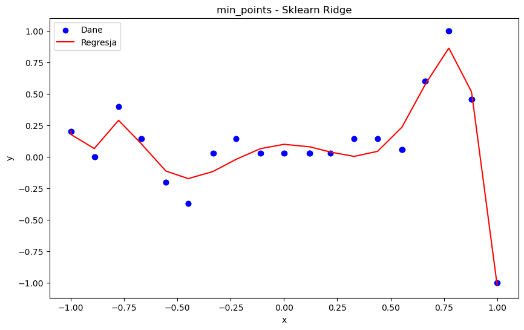

```
Zbiór danych: only_changes
Liczba punktów: 187
Własna implementacja - MSE: 0.010542699028346172
```

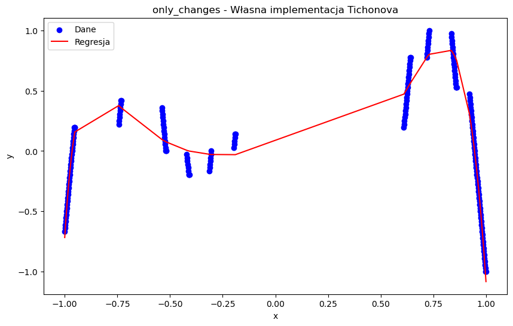

```
Sklearn Ridge - MSE: 0.010542713283299724
```

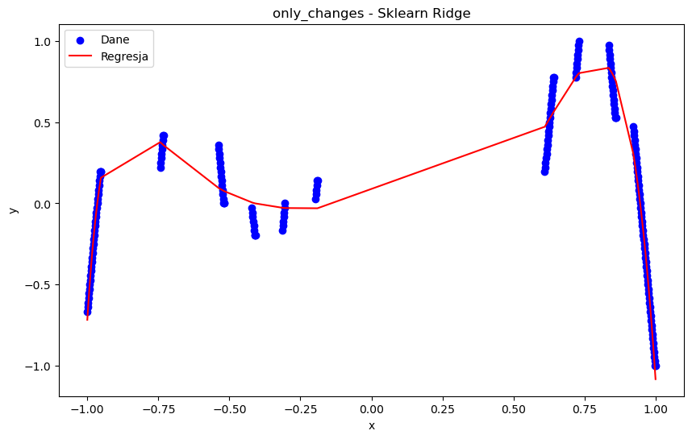

```python
mse_results = {"Sklearn": [], "Analytical": []}
print("Porównanie algorytmów Tichonova")


for name, x, y in datasets:
    print(f"Zbiór danych: {name}\nLiczba punktów: {len(x)}")

    y_pred_custom, mse_custom = regression_with_Tichonov(x, y, alpha, degree)
    mse_results["Analytical"].append(mse_custom)

    print(f"Własna implementacja - MSE: {mse_custom}")
    plot_results(x, y, y_pred_custom, f"{name} - Własna implementacja Tichonova")

    y_pred_sklearn, mse_sklearn = regression_with_Tichonov_model_ridge(x, y, alpha, degree)
    mse_results["Sklearn"].append(mse_sklearn)

    print(f"Sklearn Ridge - MSE: {mse_sklearn}")
    plot_results(x, y, y_pred_sklearn, f"{name} - Sklearn Ridge")
```

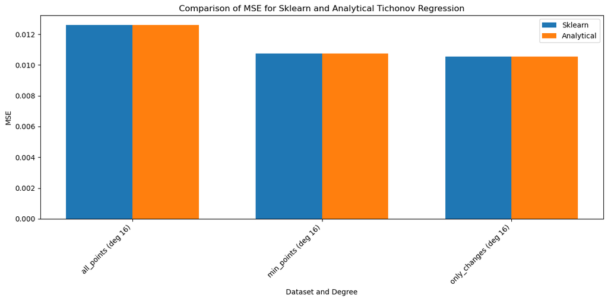

```python
def generate_comparison_plot(mse_results, datasets, degrees):
    labels = [name for name, _, _ in datasets]
    x_labels = [f"{name} (deg {degree})" for name in labels for degree in degrees]
    x = np.arange(len(x_labels))

    width = 0.35
    plt.figure(figsize=(12, 6))
    plt.bar(x - width/2, mse_results["Sklearn"], width, label="Sklearn")
    plt.bar(x + width/2, mse_results["Analytical"], width, label="Analytical")
    plt.xlabel("Dataset and Degree")
    plt.ylabel("MSE")
    plt.title("Comparison of MSE for Sklearn and Analytical Tichonov Regression")
    plt.xticks(x, x_labels, rotation=45, ha="right")
    plt.legend()
    plt.tight_layout()
    plt.show()

generate_comparison_plot(mse_results, datasets, [degree])
```